# Summary report of short-term forecasts for viral respiratory diseases by `ViroReportR`

## Overview

`ViroReportR` package uses `EpiEstim` as the backend to forecast daily confirmed cases, which forecasts cases by estimating the instantaneous reproduction number using the [Cori method](https://academic.oup.com/aje/article/178/9/1505/89262) and then simulating the number of new cases using fixed exponential growth over a given time period. This model is designed for short-term forecasting, and its predictive accuracy decreases when extending beyond the optimal 7-14 days horizon.

## Key Functionality

### Core Forecasting Function

#### `forecast_epiestim()`

**Purpose:** Main wrapper function that combines data cleaning, model fitting, and forecast generation into one step.

**Key Steps**

1. Checks data format and ensures there are at least 14 days of data.
2. Filters data after the provided `start_date`.
3. Removes pre-epidemic zero-case days.
4. Optionally smooths data using `smooth_model_data()`.
5. Fits reproduction model and generates forecasts.
6. Summarizes results with quantile estimates.

**Arguments**

| Argument | Description |
| --- | --- |
| **data** | Data frame with `date` and `confirm` columns. |
| **start_date** | Start date of epidemic period. |
| **window_size** | Rolling window size for $R_t$ estimation. |
| **n_days** | Forecast horizon (default = 7 days). |
| **type** | Epidemic type (`"flu_a"`, `"flu_b"`, `"rsv"`, `"sars_cov2"`, `"custom"`). |
| **smooth_data** | Logical; whether to smooth input curve. |
| **smoothing_cutoff** | Minimum rows required for smoothing (default = 10). |
| **…** | Extra parameters passed to `fit_epiestim_model()`. |

**Returns**

Data frame containing: - `date`: forecast date - `p025`, `p25`, `p50`, `p75`, `p975`: forecast quantiles - `min_sim`, `max_sim`: forecast range

### Supporting Functions

| Function | Description |
| --- | --- |
| **`fit_epiestim_model()`** | Function to estimate the reproduction number of epidemics to support short-term forecasts. |
| **`generate_forecasts()`** | Produce short-term daily projections. |
| **`smooth_model_data()`** | Applies P-spline smoothing using a Generalized Additive Model (GAM) to the input model data. |

### Model Validation and Visualization

#### `forecast_time_period()`

**Purpose:** This function runs the forecasting routine across a specified evaluation window. It returns a structured object containing both observed and predicted values for each evaluation period.

**Arguments**

| Argument | Description |
| --- | --- |
| **data** | Data frame with `date` and `confirm` columns. |
| **start_date** | Beginning of the evaluation window. |
| **time_period** | Evaluation granularity (“daily”, “weekly”, etc.). |
| **n_days** | Forecast horizon (default = 7 days). |
| **type** | Disease type (`"flu_a"`, `"flu_b"`, `"rsv"`, `"sars_cov2"`, `"custom"`). |
| **algorithm** | Forecasting algorithm used — here, “EpiEstim”. |
| **…** | Extra parameters passed to `fit_epiestim_model()`. |

#### `plot_validation()`

This function visualizes the comparison between observed and predicted incidence. The pred_plot = “ribbon” option displays prediction intervals as shaded regions around the median forecast.

The resulting plot includes: - Black points: observed incidence. - Blue line: median predicted incidence (p50). - Shaded ribbon: forecast uncertainty (e.g., 25th–75th percentile).

## Example Workflow

### Create simulate data

In this workflow, we simulate RSV incidence data, format it for analysis, and generate short-term forecasts using the EpiEstim-based forecasting functions. We demonstrate the impact of smoothing on forecast results.

```r
# create simulate RSV data
disease_type <- "rsv"
test_data <- simulate_data(noise_sd=5)
formatted_data <- get_aggregated_data(
  test_data,
  number_column = disease_type,
  date_column = "date",
  start_date = "2024-04-01",
  end_date = "2024-05-01"
)
```

### Running Forecasts

We generate two forecasts:

With smoothing – reduces noise in observed case counts to stabilize the {R_t}estimation.

```r
# Run forecasting with smoothing
res_smooth <- forecast_epiestim(
  data = formatted_data,
  start_date = "2024-04-01",
  n_days = forecast_horizon,
  type = "rsv",
  smooth_data = T
)

# Run forecasting without smoothing
res_non_smooth <- forecast_epiestim(
  data = formatted_data,
  start_date = "2024-04-01",
  n_days = forecast_horizon,
  type = "rsv",
  smooth_data = F
)
```

### Viewing Forecast Results

The resulting objects (`res_smooth` and `res_non_smooth`) are lists containing daily forecast quantiles, including: - p025 – 2.5th percentile - p25 – 25th percentile - p50 – median prediction - p75 – 75th percentile - p975 – 97.5th percentile

Each row corresponds to a forecasted day, and the columns contain the forecast median and uncertainty intervals.

*Smoothed Forecast Result*

```r
res_smooth
```

```
## # A tibble: 7 x 8
##   date         p50   p25   p75  p025  p975 min_sim max_sim
##   <date>     <dbl> <dbl> <dbl> <dbl> <dbl>   <int>   <int>
## 1 2024-05-02    29    25    33  19    41        16      47
## 2 2024-05-03    28    25    32  18    39        14      44
## 3 2024-05-04    27    24    31  17    39        12      47
## 4 2024-05-05    26    23    30  17    37        12      48
## 5 2024-05-06    25    22    28  16    34.0      12      41
## 6 2024-05-07    25    21    29  16    36        10      46
## 7 2024-05-08    24    21    28  15.0  36        11      42
```

*Non-Smoothed Forecast Result*

```r
res_non_smooth
```

```
## # A tibble: 7 x 8
##   date         p50   p25   p75  p025  p975 min_sim max_sim
##   <date>     <dbl> <dbl> <dbl> <dbl> <dbl>   <int>   <int>
## 1 2024-05-02    27  24      31    18  38        14      46
## 2 2024-05-03    26  23      29    17  36        10      43
## 3 2024-05-04    24  21      28    16  35.0       9      42
## 4 2024-05-05    23  20      27    15  34         8      41
## 5 2024-05-06    22  19.8    26    14  33         7      40
## 6 2024-05-07    23  19      26    13  33         9      38
## 7 2024-05-08    22  19      25    14  33        10      43
```

### Visualizing Forecasts

We can visualize forecasts using ribbon plots, where:

- The shaded ribbon represents the 50% prediction interval.
- The blue line shows the median forecast.
- Observed case counts are plotted as black points for comparison.

*Smoothed Forecast Plot*

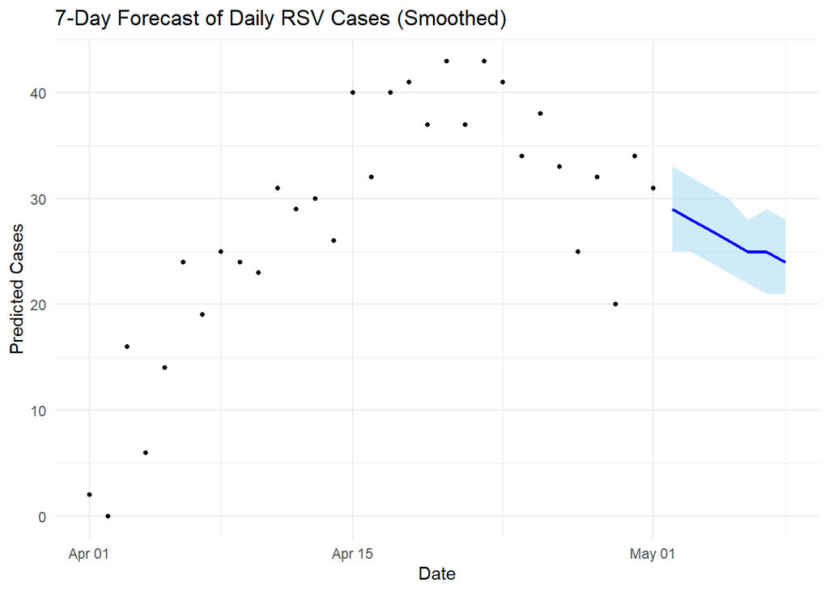

```r
ggplot(res_smooth, aes(x = date)) +
  geom_ribbon(aes(ymin = p25, ymax = p75), fill = "skyblue", alpha = 0.4) +
  geom_line(aes(y = p50), color = "blue", size = 1) +
  geom_point(data = formatted_data, aes( x = date, y = confirm), color = "black", size = 1) +
  labs(
    title = paste0(forecast_horizon, "-Day Forecast of Daily RSV Cases (Smoothed)"),
    x = "Date", y = "Predicted Cases"
  ) +
  theme_minimal()
```

*Non-Smoothed Forecast Plot*

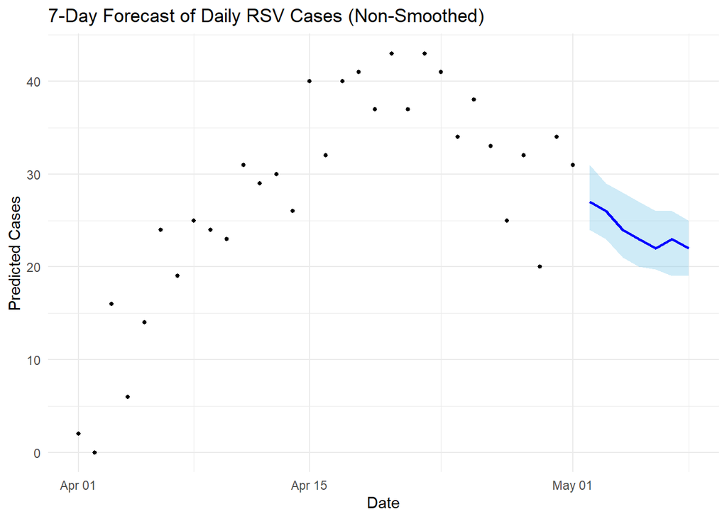

```r
ggplot(res_non_smooth, aes(x = date)) +
  geom_ribbon(aes(ymin = p25, ymax = p75), fill = "skyblue", alpha = 0.4) +
  geom_line(aes(y = p50), color = "blue", size = 1) +
  geom_point(data = formatted_data, aes( x = date, y = confirm), color = "black", size = 1) +
  labs(
    title = paste0(forecast_horizon, "-Day Forecast of Daily RSV Cases (Non-Smoothed)"),
    x = "Date", y = "Predicted Cases"
  ) +
  theme_minimal()
```

## Validation

This section demonstrates how to validate the forecast model by comparing predicted values against observed data over a specified time period.

```r
time_period_result_daily <- forecast_time_period(
  data = formatted_data,
  start_date = "2024-04-01",
  n_days = forecast_horizon,
  type = "rsv",
  time_period = "daily",
  algorithm = "EpiEstim"
)
```

The validation results can be visualized using plot_validation(), which overlays predicted intervals and observed data points.

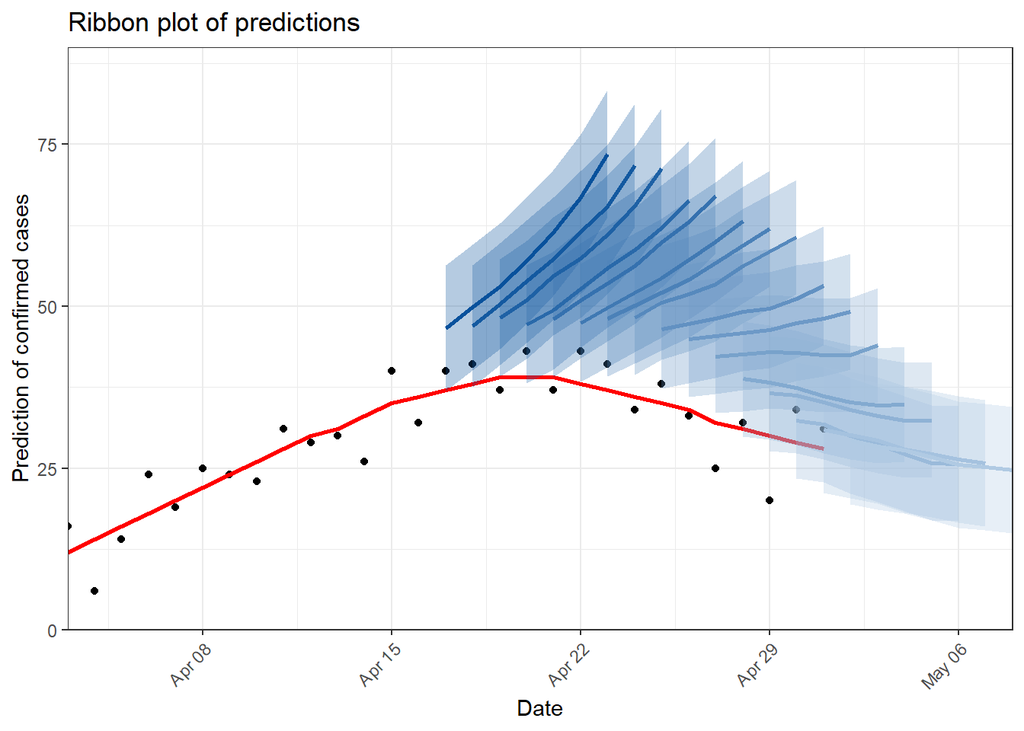

```r
plot_validation(time_period_result_daily, pred_plot = "ribbon") +
  ggplot2::coord_cartesian(ylim=c(0,90),expand=FALSE)
```